# Ball Bearing Fault Analysis

SHMTools Example - Condition-Based Monitoring

← Back to Index [GitHub Repository](https://github.com/shmtools/shmtools-python) [Documentation](https://shmtools.readthedocs.io)

# Condition Based Monitoring Ball Bearing Fault Analysis

## Introduction:

This example goes through a recommended semi-automated procedure outlined in Vibration-based Condition Monitoring by R. Randall. The data was collected from a machinery fault simulator with roller bearings supporting a shaft with a gear box attached to it and being driven by a belt drive. The script proceeds to remove periodic frequency components generated by the gearbox which tends to drown out the bearing fault vibrations. To remove the periodic components the signals first needed to be resampled to the gear shaft angular domain. The random components associated with bearing damage are separated and compared to determine if filtering and demodulation are appropriate for the signal to maximize the detection of the ball bearing roller fault. In this example it turns out that the random component signal is optimal and no demodulation was needed. Then some damage features are computed for a number of instances containing modified vibration signals from a healthy bearing and a bearing with a roller element fault to compare the detection capabilities of each damage feature using receiver operating characteristic curves.

Requires data_CBM.mat dataset.

**References:**

[1] Randall, Robert., Vibration-based Condition Monitoring, Wiley and Sons, 2011.

**SHMTools functions called:**

- import_cbm_data_shm
- demean_shm
- psd_welch_shm
- ars_tach_shm
- envelope_shm
- crest_factor_shm
- stat_moments_shm
- roc_shm
- plot_roc_shm

```python
import numpy as np
import matplotlib.pyplot as plt
import sys
sys.path.append('../..')

# Import SHMTools functions
from examples.data.data_imports import import_cbm_data_shm
from shmtools.core.preprocessing import demean_shm, envelope_shm
from shmtools.core.spectral import psd_welch_shm
from shmtools.core.cbm_processing import ars_tach_shm
from shmtools.core.statistics import crest_factor_shm, stat_moments_shm
from shmtools.classification.outlier_detection import roc_shm
from shmtools.plotting.spectral_plots import plot_roc_shm
```

## Begin Bearing Damage Analysis Script

```python
# Load Desired Data States and Channels for Outer Race Bearing Damage w/
# Channel 3: Accel Mounted on Top of Bearing Housing
dataset, damage_states, state_list, Fs = import_cbm_data_shm()

print(f"Dataset shape: {dataset.shape}")
print(f"Sampling frequency: {Fs} Hz")
print(f"Unique states: {np.unique(state_list)}")
print(f"Damage states shape: {damage_states.shape}")
```

```
Dataset shape: (10240, 4, 384)
Sampling frequency: 2048.0 Hz
Unique states: [1 2 3 4 5 6]
Damage states shape: (384, 1)
```

```python
# Select states 5 (baseline) and 6 (damaged bearing)
states = (state_list.flatten() == 5) | (state_list.flatten() == 6)
channels = [0, 2]  # tachometer (channel 0) and accel (channel 2)

X = dataset[:, channels, :][:, :, states]
damage_states_filtered = damage_states[states]
state_list_filtered = state_list.flatten()[states]

# Find baseline and damage indices
i_baseline = np.where(state_list_filtered == 5)[0]
i_damage = np.where(state_list_filtered == 6)[0]

print(f"Filtered dataset shape: {X.shape}")
print(f"Baseline instances: {len(i_baseline)}")
print(f"Damaged instances: {len(i_damage)}")

# Remove mean from signals
X = demean_shm(X)
```

```
Filtered dataset shape: (10240, 2, 128)
Baseline instances: 64
Damaged instances: 64
```

## 1) Look at an Example Time and Frequency Series

[figure not shown]

```
From the raw time signal and FFT you can see that the fundamental gear mesh
frequency is approximately 120Hz and its harmonics are integer multiples
(120Hz, 240Hz, 360Hz...) which dominate even though the data was retrieved
from a sensor relatively distant from the gear box. These periodic
components need to be removed from the vibration signal.
```

```python
# Plot Instance Number
instance = min(15, len(i_baseline)-1)  # Use available instance

fig, axes = plt.subplots(3, 2, figsize=(14, 12))

# Time Series Comparison
axes[0, 0].plot(X[:512, 1, i_baseline[instance]], 'b', label='Baseline')
axes[0, 0].plot(X[:512, 1, i_damage[instance]], 'r', label='Damaged')
axes[0, 0].set_title('Time Series Data, First 512 points')
axes[0, 0].set_xlabel('Sample')
axes[0, 0].set_ylabel('Acceleration (g)')
axes[0, 0].legend()
axes[0, 0].grid(True)

# Frequency Domain Comparison
baseline_signal = X[:, 1, i_baseline[instance]].reshape(-1, 1, 1)
damage_signal = X[:, 1, i_damage[instance]].reshape(-1, 1, 1)
combined_signal = np.concatenate([baseline_signal, damage_signal], axis=2)

psd_matrix, f, is_one_sided = psd_welch_shm(combined_signal, fs=Fs)

# Plot up to 600 Hz
freq_mask = f <= 600
axes[0, 1].plot(f[freq_mask], psd_matrix[freq_mask, 0, 0], 'b', label='Baseline')
axes[0, 1].plot(f[freq_mask], psd_matrix[freq_mask, 0, 1], 'r', label='Damaged')
axes[0, 1].set_title('PSD Magnitude Plot')
axes[0, 1].set_xlabel('Frequency (Hz)')
axes[0, 1].set_ylabel('Magnitude')
axes[0, 1].legend()
axes[0, 1].grid(True)

plt.tight_layout()
plt.show()

print("From the raw time signal and FFT you can see that the fundamental gear mesh")
print("frequency is approximately 120Hz and its harmonics are integer multiples")
print("(120Hz, 240Hz, 360Hz...) which dominate even though the data was retrieved")
print("from a sensor relatively distant from the gear box. These periodic")
print("components need to be removed from the vibration signal.")
```

## 2A) Order Track using ARS Tach

The data in this example was retrieved from a system that had minor speed fluctuations in the main shaft speed. The shaft speed variation was on the order or +/- 3RPM. The ars_tach_shm uses a single pulse per rotation signal to resample a time domain signal that may have large speed fluctuations into a vibration signal tracked to orders of the shaft rotation in an equally space angular domain. This improves periodic frequency components that would have smeared from shaft speed fluctuations. The tachometer is located on the main shaft but the gear box is separated by a belt drive with a gear ratio equal to 1:3.71 and must be accounted for to resample to the gearbox shaft.

```python
# ARS Tach Input Parameters:
n_filter = 255        # Anti-Alias Filter Length
samples_per_rev = 256 # Desired Samples per Rev
gear_ratio = 1/3.71   # Main Shaft:Gear Shaft Ratio

print(f"Angular resampling parameters:")
print(f"Filter length: {n_filter}")
print(f"Samples per revolution: {samples_per_rev}")
print(f"Gear ratio: {gear_ratio}")

# Angular resample using tachometer
x_ars_matrix_t, actual_spr = ars_tach_shm(X, n_filter, samples_per_rev, gear_ratio)

print(f"\nAngular resampled matrix shape: {x_ars_matrix_t.shape}")
print(f"Actual samples per revolution: {actual_spr}")
```

```
Angular resampling parameters:
Filter length: 255
Samples per revolution: 256
Gear ratio: 0.2695417789757412
```

```
Angular resampled matrix shape: (4864, 1, 128)
Actual samples per revolution: 256
```

## Compare Resampled Angular Series and Frequency Domain Content

[figure not shown]

```python
fig, axes = plt.subplots(3, 2, figsize=(14, 12))

# Add to previous plot - Angular Series Comparison
rev_axis = np.arange(actual_spr) / actual_spr
axes[1, 0].plot(rev_axis, x_ars_matrix_t[:actual_spr, 0, i_baseline[instance]], 'b', label='Baseline')
axes[1, 0].plot(rev_axis, x_ars_matrix_t[:actual_spr, 0, i_damage[instance]], 'r', label='Damaged')
axes[1, 0].set_title(f'Angular Resampled Signal using Tachometer\n1 Gear Revolution, SPR: {actual_spr}')
axes[1, 0].set_xlabel('Revolutions')
axes[1, 0].set_ylabel('Acceleration (g)')
axes[1, 0].legend()
axes[1, 0].grid(True)

# Frequency Domain Comparison (Angular Domain)
baseline_ars = x_ars_matrix_t[:, 0, i_baseline[instance]].reshape(-1, 1, 1)
damage_ars = x_ars_matrix_t[:, 0, i_damage[instance]].reshape(-1, 1, 1)
combined_ars = np.concatenate([baseline_ars, damage_ars], axis=2)

psd_ars, f_ars, _ = psd_welch_shm(combined_ars, fs=actual_spr/27)  # Convert to gear mesh orders

# Plot first 5 orders
order_mask = f_ars <= 5
axes[1, 1].plot(f_ars[order_mask], psd_ars[order_mask, 0, 0], 'b', label='Baseline')
axes[1, 1].plot(f_ars[order_mask], psd_ars[order_mask, 0, 1], 'r', label='Damaged')
axes[1, 1].set_title(f'PSD Magnitude Plot using Tachometer\nFirst 5 Orders, SPR: {actual_spr}')
axes[1, 1].set_xlabel('Frequency (Gear Mesh Orders)')
axes[1, 1].set_ylabel('Magnitude')
axes[1, 1].legend()
axes[1, 1].grid(True)

# Remove the top row axes since we're not using arsAccel
axes[0, 0].set_visible(False)
axes[0, 1].set_visible(False)

plt.tight_layout()
plt.show()
```

## 3) Simple Random Component Extraction

```python
from scipy import signal as sig

def simple_random_separation(x_ars, cutoff_order=0.2):
    """
    Simple high-pass filtering to extract random components.
    This removes low-frequency periodic gear mesh components.
    """
    # Design high-pass filter
    # cutoff_order is normalized frequency (0-1)
    b, a = sig.butter(4, cutoff_order, btype='high')

    # Apply filter to each channel and instance
    x_random = np.zeros_like(x_ars)
    for ch in range(x_ars.shape[1]):
        for inst in range(x_ars.shape[2]):
            x_random[:, ch, inst] = sig.filtfilt(b, a, x_ars[:, ch, inst])

    return x_random

# Extract random components
x_random_matrix = simple_random_separation(x_ars_matrix_t)

print(f"Random component matrix shape: {x_random_matrix.shape}")
```

```
Random component matrix shape: (4864, 1, 128)
```

## Compare Random Components and Frequency Domain Content

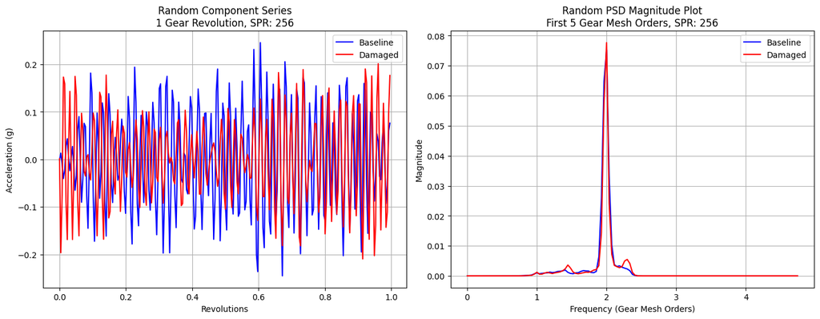

```python
fig, axes = plt.subplots(2, 2, figsize=(14, 10))

# Random Series Comparison
axes[0, 0].plot(rev_axis, x_random_matrix[:actual_spr, 0, i_baseline[instance]], 'b', label='Baseline')
axes[0, 0].plot(rev_axis, x_random_matrix[:actual_spr, 0, i_damage[instance]], 'r', label='Damaged')
axes[0, 0].set_title(f'Random Component Series\n1 Gear Revolution, SPR: {actual_spr}')
axes[0, 0].set_xlabel('Revolutions')
axes[0, 0].set_ylabel('Acceleration (g)')
axes[0, 0].legend()
axes[0, 0].grid(True)

# Random Frequency Domain Comparison
baseline_random = x_random_matrix[:, 0, i_baseline[instance]].reshape(-1, 1, 1)
damage_random = x_random_matrix[:, 0, i_damage[instance]].reshape(-1, 1, 1)
combined_random = np.concatenate([baseline_random, damage_random], axis=2)

psd_random, f_random, _ = psd_welch_shm(combined_random, fs=actual_spr/27)

# Plot first 5 orders
order_mask_random = f_random <= 5
axes[0, 1].plot(f_random[order_mask_random], psd_random[order_mask_random, 0, 0], 'b', label='Baseline')
axes[0, 1].plot(f_random[order_mask_random], psd_random[order_mask_random, 0, 1], 'r', label='Damaged')
axes[0, 1].set_title(f'Random PSD Magnitude Plot\nFirst 5 Gear Mesh Orders, SPR: {actual_spr}')
axes[0, 1].set_xlabel('Frequency (Gear Mesh Orders)')
axes[0, 1].set_ylabel('Magnitude')
axes[0, 1].legend()
axes[0, 1].grid(True)

# Remove unused subplots
axes[1, 0].set_visible(False)
axes[1, 1].set_visible(False)

plt.tight_layout()
plt.show()
```

## 4) Compute the Demodulated Enveloped Signal of the Random Component

```
Envelope matrix shape: (4864, 1, 128)
```

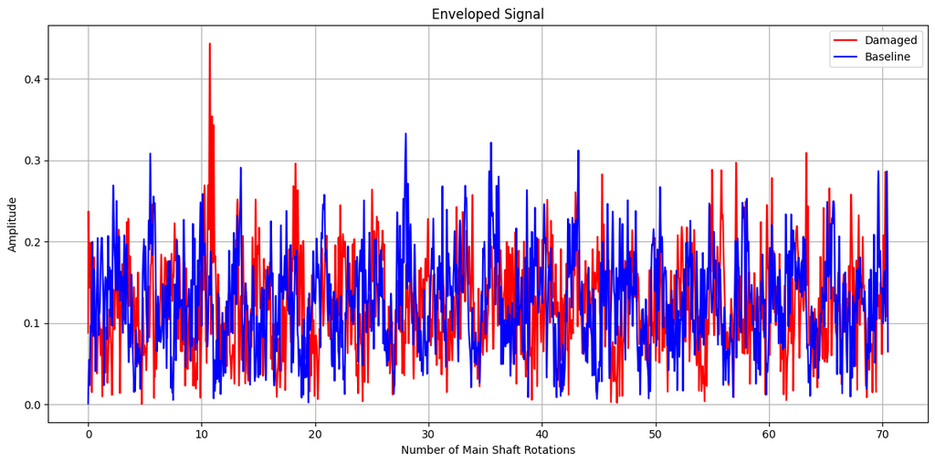

```
The plot shows when impulses from the ball bearing elements
are actively hitting a fault.
```

```python
# Compute envelope of random component
envelope_matrix = envelope_shm(x_random_matrix)

print(f"Envelope matrix shape: {envelope_matrix.shape}")

# Plot enveloped signal
fig, ax = plt.subplots(figsize=(12, 6))

# Convert to main shaft rotations
rotation = np.arange(envelope_matrix.shape[0]) / gear_ratio / actual_spr
ax.plot(rotation, envelope_matrix[:, 0, i_damage[instance]], 'r', label='Damaged')
ax.plot(rotation, envelope_matrix[:, 0, i_baseline[instance]], 'b', label='Baseline')
ax.set_title('Enveloped Signal')
ax.set_xlabel('Number of Main Shaft Rotations')
ax.set_ylabel('Amplitude')
ax.legend()
ax.grid(True)

plt.tight_layout()
plt.show()

print("The plot shows when impulses from the ball bearing elements")
print("are actively hitting a fault.")
```

```python
# Compute Matrix Damage Features

# Raw Signal Damage Features (using channel 1 - accelerometer)
raw_signals = X[:, 1, :].reshape(X.shape[0], 1, X.shape[2])  # Shape for SHM functions
cf_raw = crest_factor_shm(raw_signals).flatten()
statistics_fv_raw = stat_moments_shm(raw_signals)
variance_raw = statistics_fv_raw[:, 1]  # Second moment (variance)
kurt_raw = statistics_fv_raw[:, 3]     # Fourth moment (kurtosis)

# Envelope Signal Damage Features
envelope_signals = envelope_matrix[:, 0, :].reshape(envelope_matrix.shape[0], 1, envelope_matrix.shape[2])
cf_envelope = crest_factor_shm(envelope_signals).flatten()
statistics_fv_envelope = stat_moments_shm(envelope_signals)
variance_envelope = statistics_fv_envelope[:, 1]  # Second moment (variance)
kurt_envelope = statistics_fv_envelope[:, 3]      # Fourth moment (kurtosis)

print(f"Number of instances: {len(cf_raw)}")
print(f"Baseline instances: {len(i_baseline)}")
print(f"Damaged instances: {len(i_damage)}")

# Create feature matrix
features = np.column_stack([
    cf_raw, cf_envelope,
    variance_raw, variance_envelope,
    kurt_raw, kurt_envelope
])

feat_names = [
    'Raw Crest Factor', 'Envelope Crest Factor',
    'Raw Variance', 'Envelope Variance',
    'Raw Kurtosis', 'Envelope Kurtosis'
]

print(f"Features matrix shape: {features.shape}")
```

```
Number of instances: 128
Baseline instances: 64
Damaged instances: 64
Features matrix shape: (128, 6)
```

## 5) Look at Some Feature Types

To be compared are 6 damage types. The following damage types are crest factor, kurtosis, and variance which are calculated using the enveloped signal of the random component after gear mesh frequencies have been removed. To see if any improvement in detectability has been achieved a comparison is made against the same damage features of the raw signal with no processing at all which has been used in some studies of ball bearing damage.

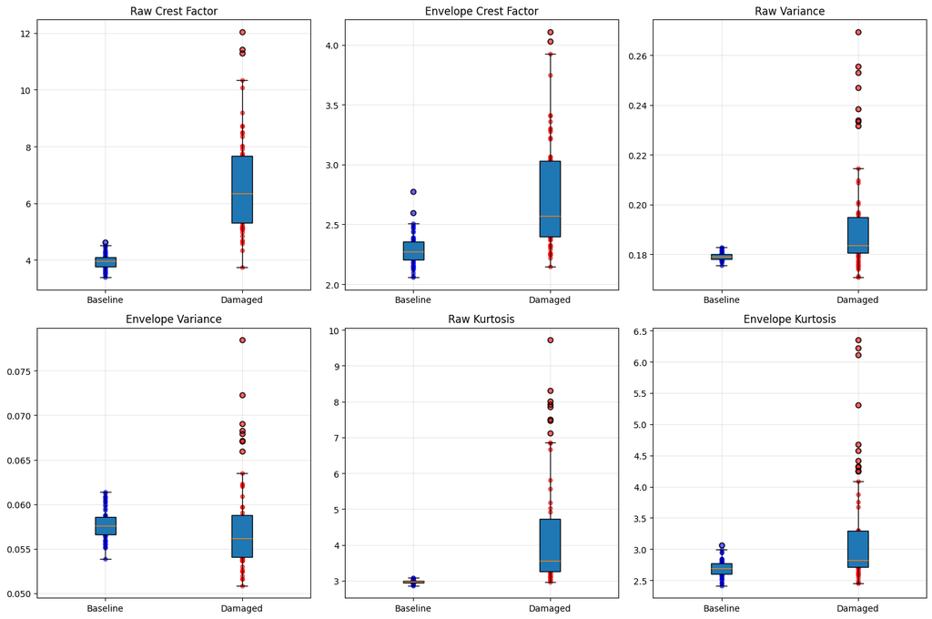

```python
# Plot feature comparison
fig, axes = plt.subplots(2, 3, figsize=(15, 10))
axes = axes.flatten()

for i, feat_name in enumerate(feat_names):
    # Separate baseline and damaged features
    baseline_feat = features[i_baseline, i]
    damaged_feat = features[i_damage, i]

    # Box plot comparison
    axes[i].boxplot([baseline_feat, damaged_feat],
                    labels=['Baseline', 'Damaged'],
                    patch_artist=True)
    axes[i].set_title(feat_name)
    axes[i].grid(True, alpha=0.3)

    # Add scatter points
    x_baseline = np.ones(len(baseline_feat))
    x_damaged = 2 * np.ones(len(damaged_feat))
    axes[i].scatter(x_baseline, baseline_feat, alpha=0.6, color='blue', s=20)
    axes[i].scatter(x_damaged, damaged_feat, alpha=0.6, color='red', s=20)

plt.tight_layout()
plt.show()
```